# Practical Machine Learning Course Writeup

Predicting Quality of Weight Lifting Exercise

Adeline Ong

16 June 2015

## **Introduction**

In this project, our goal is to quantify how well people are doing weight lifting exercise. Data are collected with fitted accelerometers on the belt, forearm, arm and dumbbell. Participants were asked to perform weight lifting exercise with dumbbell correctly and incorrectly in 5 different ways as follows:

Class A - According to the specification Class B - Throwing the elbow to the front Class C - Lifting the dumbbell only halfway Class D - Lowering the dumbbell only halfway Class E - Throwing the hips to the front

The data used in this report come from this source: http://groupware.les.inf.puc-rio.br/har

## **PreProcessing**

We begin by loading nescessary library, the training and testing dataset into R.

```r
library(caret)
library(rattle)
library(kernlab)
```

In order to save R processing time, we first drop variables that are unnessecary for the prediction model. The variables that were dropped were user name, timestamp and window information that will not contribute to the prediction.

```r
pml1<-pml[c( -1:-7)]
```

Before any analysis is performed, we identify many predictors with missing observations and decided to remove any such predictors.

```r
pml2<-pml1[,colSums(is.na(pml1))/nrow(pml1)<0.9]
```

## **Data Processing**

We split our training dataset into 60% training, 20% testing and 20% validation and set the seed to 1234 for this analysis.

```r
inBuild<-createDataPartition(y=pml2$classe, p=0.6, list=FALSE)
training<-pml2[inBuild,]
nontraining<-pml2[-inBuild,]

inTest<-createDataPartition(y=nontraining$classe, p=0.5, list=FALSE)
testing<-nontraining[inTest,]
validate<-nontraining[-inTest,]

set.seed(1234)
```

## **Analysis**

### **CART**

We build our first model using a simple CART (classification and regression tree) model as it is easy to interpret and provide visualization of the data.

```r
modelfit_rpart<-train(classe~.,data=training,method="rpart")
print(modelfit_rpart)
```

```
## CART
##
## 11776 samples
##    52 predictor
##     5 classes: 'A', 'B', 'C', 'D', 'E'
##
## No pre-processing
## Resampling: Bootstrapped (25 reps)
##
## Summary of sample sizes: 11776, 11776, 11776, 11776, 11776, 11776, ...
##
## Resampling results across tuning parameters:
##
##   cp          Accuracy   Kappa       Accuracy SD  Kappa SD
##   0.03618889  0.5156058  0.37048840  0.03640092   0.06107493
##   0.06011707  0.3955504  0.17542638  0.05858483   0.09480972
##   0.11544850  0.3283029  0.06832624  0.04163045   0.06195128
##
## Accuracy was used to select the optimal model using  the largest value.
## The final value used for the model was cp = 0.03618889.
```

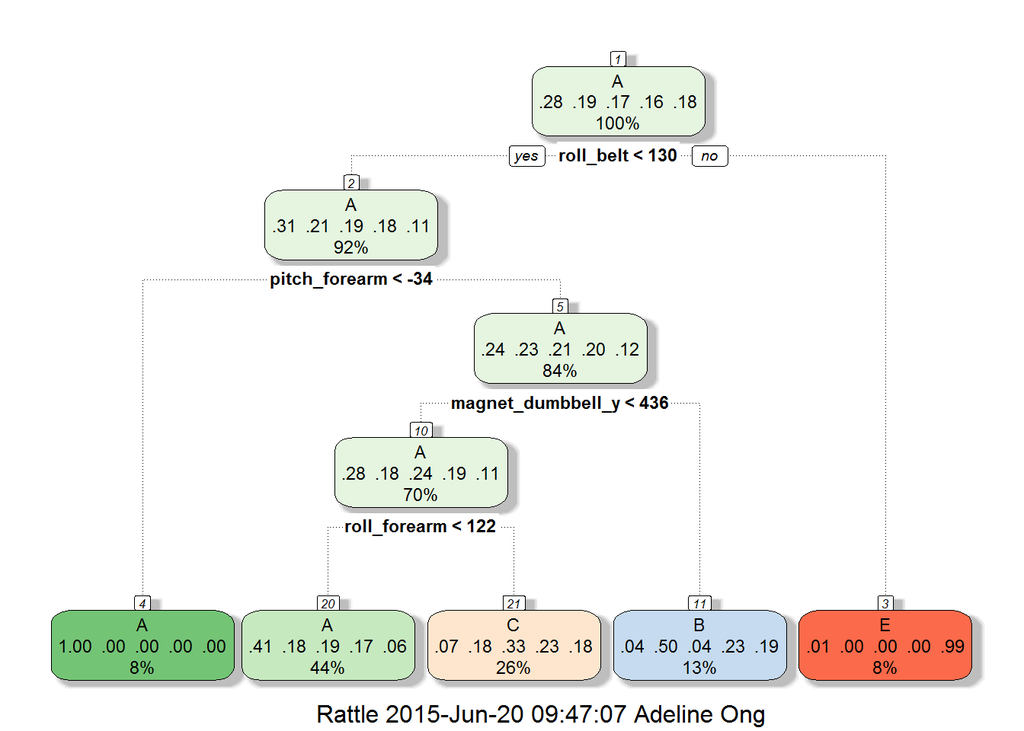

```r
fancyRpartPlot(modelfit_rpart$finalModel)
```

```r
predict_rpart<-predict(modelfit_rpart, newdata=testing)
print(confusionMatrix(predict_rpart, testing$classe))
```

```
## Confusion Matrix and Statistics
##
##           Reference
## Prediction   A   B   C   D   E
##          A 996 314 307 265 106
##          B  23 261  26 113 100
##          C  93 184 351 265 184
##          D   0   0   0   0   0
##          E   4   0   0   0 331
##
## Overall Statistics
##
##                Accuracy : 0.4943
##                  95% CI : (0.4785, 0.51)
##     No Information Rate : 0.2845
##     P-Value [Acc > NIR] : < 2.2e-16
##
##                   Kappa : 0.3402
##  Mcnemar's Test P-Value : NA
##
## Statistics by Class:
##
##                      Class: A Class: B Class: C Class: D Class: E
## Sensitivity            0.8925  0.34387  0.51316   0.0000  0.45908
## Specificity            0.6466  0.91719  0.77586   1.0000  0.99875
## Pos Pred Value         0.5010  0.49904  0.32591      NaN  0.98806
## Neg Pred Value         0.9380  0.85353  0.88299   0.8361  0.89130
## Prevalence             0.2845  0.19347  0.17436   0.1639  0.18379
## Detection Rate         0.2539  0.06653  0.08947   0.0000  0.08437
## Detection Prevalence   0.5068  0.13332  0.27453   0.0000  0.08539
## Balanced Accuracy      0.7695  0.63053  0.64451   0.5000  0.72892
```

From the classification tree, it does not predict class D and with the low accuracy, we will fit random forest model next which can improve the accuracy and classification rate.

### **Random Forest**

For the random forest model, we fit the model with 5-fold cross validation.

```r
modelfit_rf<-train(classe~.,data=training,method="rf", prox=TRUE, trControl=trainControl(method="cv", number=5))
predict_rf<-predict(modelfit_rf, newdata=testing)
print(confusionMatrix(predict_rf, testing$classe))
```

```
## Confusion Matrix and Statistics
##
##           Reference
## Prediction    A    B    C    D    E
##          A 1116    9    0    0    0
##          B    0  749    3    0    0
##          C    0    1  675    8    1
##          D    0    0    6  632    1
##          E    0    0    0    3  719
##
## Overall Statistics
##
##                Accuracy : 0.9918
##                  95% CI : (0.9885, 0.9944)
##     No Information Rate : 0.2845
##     P-Value [Acc > NIR] : < 2.2e-16
##
##                   Kappa : 0.9897
##  Mcnemar's Test P-Value : NA
##
## Statistics by Class:
##
##                      Class: A Class: B Class: C Class: D Class: E
## Sensitivity            1.0000   0.9868   0.9868   0.9829   0.9972
## Specificity            0.9968   0.9991   0.9969   0.9979   0.9991
## Pos Pred Value         0.9920   0.9960   0.9854   0.9890   0.9958
## Neg Pred Value         1.0000   0.9968   0.9972   0.9967   0.9994
## Prevalence             0.2845   0.1935   0.1744   0.1639   0.1838
## Detection Rate         0.2845   0.1909   0.1721   0.1611   0.1833
## Detection Prevalence   0.2868   0.1917   0.1746   0.1629   0.1840
## Balanced Accuracy      0.9984   0.9929   0.9919   0.9904   0.9981
```

We try to reduce the number of predictors using varImp, by fitting the random forest model with 20 most important

```r
rfImp<-varImp(modelfit_rf, scale=FALSE)
print(rfImp, type="html")
```

```
## rf variable importance
##
##   only 20 most important variables shown (out of 52)
##
##                      Overall
## roll_belt             1186.5
## pitch_forearm          731.2
## yaw_belt               650.4
## pitch_belt             551.1
## magnet_dumbbell_y      548.7
## magnet_dumbbell_z      532.3
## roll_forearm           520.9
## accel_dumbbell_y       314.8
## accel_forearm_x        226.7
## roll_dumbbell          217.1
## magnet_belt_z          206.5
## magnet_dumbbell_x      205.9
## accel_belt_z           198.9
## accel_dumbbell_z       191.3
## total_accel_dumbbell   184.4
## magnet_forearm_z       183.9
## magnet_belt_y          174.6
## yaw_arm                141.1
## magnet_belt_x          137.1
## gyros_belt_z           133.9
```

```r
modelfit_rfImp<-train(classe~.,data=training_rfImp,method="rf", prox=TRUE, trControl=trainControl(method="cv", number=5))
print(modelfit_rfImp)
```

```
## Random Forest
##
## 11776 samples
##    20 predictor
##     5 classes: 'A', 'B', 'C', 'D', 'E'
##
## No pre-processing
## Resampling: Cross-Validated (5 fold)
##
## Summary of sample sizes: 9420, 9422, 9420, 9422, 9420
##
## Resampling results across tuning parameters:
##
##   mtry  Accuracy   Kappa      Accuracy SD  Kappa SD
##    2    0.9857338  0.9819522  0.002935691  0.003714026
##   11    0.9842055  0.9800217  0.003109469  0.003934272
##   20    0.9783464  0.9726120  0.004947115  0.006260761
##
## Accuracy was used to select the optimal model using  the largest value.
## The final value used for the model was mtry = 2.
```

```r
predict_rfImp<-predict(modelfit_rfImp, newdata=testing_rfImp)
print(confusionMatrix(predict_rfImp, testing_rfImp$classe))
```

```
## Confusion Matrix and Statistics
##
##           Reference
## Prediction    A    B    C    D    E
##          A 1116   10    0    0    0
##          B    0  741    7    0    0
##          C    0    8  676    8    0
##          D    0    0    1  632    4
##          E    0    0    0    3  717
##
## Overall Statistics
##
##                Accuracy : 0.9895
##                  95% CI : (0.9858, 0.9925)
##     No Information Rate : 0.2845
##     P-Value [Acc > NIR] : < 2.2e-16
##
##                   Kappa : 0.9868
##  Mcnemar's Test P-Value : NA
##
## Statistics by Class:
##
##                      Class: A Class: B Class: C Class: D Class: E
## Sensitivity            1.0000   0.9763   0.9883   0.9829   0.9945
## Specificity            0.9964   0.9978   0.9951   0.9985   0.9991
## Pos Pred Value         0.9911   0.9906   0.9769   0.9922   0.9958
## Neg Pred Value         1.0000   0.9943   0.9975   0.9967   0.9988
## Prevalence             0.2845   0.1935   0.1744   0.1639   0.1838
## Detection Rate         0.2845   0.1889   0.1723   0.1611   0.1828
## Detection Prevalence   0.2870   0.1907   0.1764   0.1624   0.1835
## Balanced Accuracy      0.9982   0.9870   0.9917   0.9907   0.9968
```

However, the accuracy for the reduced model appears to be lower than the full model. We decided to explore further with another model, gbm.

### **Generalized Boosted Regression Model**

Another method to reduce variance and increase prediction accuracy is boosting with trees, gbm.

```r
modelfit_gbm<-train(classe~., data=training, method="gbm", verbose=FALSE, trControl=trainControl(method="cv", number=5))
predict_gbm<-predict(modelfit_gbm, newdata=testing)
print(confusionMatrix(predict_gbm, testing$classe))
```

```
## Confusion Matrix and Statistics
##
##           Reference
## Prediction    A    B    C    D    E
##          A 1105   22    0    0    3
##          B    8  717   20    1    6
##          C    2   18  654   16    6
##          D    1    2    9  618   11
##          E    0    0    1    8  695
##
## Overall Statistics
##
##                Accuracy : 0.9658
##                  95% CI : (0.9597, 0.9713)
##     No Information Rate : 0.2845
##     P-Value [Acc > NIR] : < 2.2e-16
##
##                   Kappa : 0.9568
##  Mcnemar's Test P-Value : 0.005389
##
## Statistics by Class:
##
##                      Class: A Class: B Class: C Class: D Class: E
## Sensitivity            0.9901   0.9447   0.9561   0.9611   0.9639
## Specificity            0.9911   0.9889   0.9870   0.9930   0.9972
## Pos Pred Value         0.9779   0.9535   0.9397   0.9641   0.9872
## Neg Pred Value         0.9961   0.9868   0.9907   0.9924   0.9919
## Prevalence             0.2845   0.1935   0.1744   0.1639   0.1838
## Detection Rate         0.2817   0.1828   0.1667   0.1575   0.1772
## Detection Prevalence   0.2880   0.1917   0.1774   0.1634   0.1795
## Balanced Accuracy      0.9906   0.9668   0.9716   0.9771   0.9806
```

However, the accuracy is the lowest for the gbm as compared to the models with random forest.

## **Final Model**

Thus, our chosen final model is the random forest, full model with all predictors as it appears to have the highest accuracy. We will be using this as our final model for predicting the outcome for the testing dataset.

```r
predict_rf<-predict(modelfit_rf, newdata=validate)
print(confusionMatrix(predict_rf, validate$classe))
```

```
## Confusion Matrix and Statistics
##
##           Reference
## Prediction    A    B    C    D    E
##          A 1116    7    0    0    0
##          B    0  750    3    0    0
##          C    0    2  678    6    1
##          D    0    0    3  634    3
##          E    0    0    0    3  717
##
## Overall Statistics
##
##                Accuracy : 0.9929
##                  95% CI : (0.9897, 0.9953)
##     No Information Rate : 0.2845
##     P-Value [Acc > NIR] : < 2.2e-16
##
##                   Kappa : 0.991
##  Mcnemar's Test P-Value : NA
##
## Statistics by Class:
##
##                      Class: A Class: B Class: C Class: D Class: E
## Sensitivity            1.0000   0.9881   0.9912   0.9860   0.9945
## Specificity            0.9975   0.9991   0.9972   0.9982   0.9991
## Pos Pred Value         0.9938   0.9960   0.9869   0.9906   0.9958
## Neg Pred Value         1.0000   0.9972   0.9981   0.9973   0.9988
## Prevalence             0.2845   0.1935   0.1744   0.1639   0.1838
## Detection Rate         0.2845   0.1912   0.1728   0.1616   0.1828
## Detection Prevalence   0.2863   0.1919   0.1751   0.1631   0.1835
## Balanced Accuracy      0.9988   0.9936   0.9942   0.9921   0.9968
```

## **Prediction**

The final model is applied to the test data to predict the outcome of the 20 observation. The results of the predicted outcome is submitted separately on the course website.